# Comparing Shoreline Erosion of Reef Protected and Unprotected Coastlines after Storm Events

Do shorelines protected by reefs experience less erosion than unprotected coasts? The answer to this question should depend on the timescale. In this code I examine the short term response by analyzing a metadataset recording the beach sediment lost after a storm event passes near or onto a coastline. Typically, beaches are assessed before and after the event and a volume loss/gain per meter of beach is recorded. Some studies state the significant wave height of the storm or high wave energy event. Others do not include that information. For studies that do not have Hs, I used a similar approach to Cuttler et al. (2018) by obtaining wave watch 3 hindcast data and selecting grids manually that are nearest to the study site. For the Martins et al. (2019) study, I backcalculate significant wave height from their wave energy plot on July 2015. The equation to calculate significant wave height ($Hs$) from energy density ($E$), density of seawater ($\rho$), and acceleration due to gravity ($g$) is:

$$Hs = \sqrt{\frac{{8 \cdot E}}{{\rho \cdot g}}}$$

The following code examines the metadataset and compares erosion rates for protected and unprotected beaches after storm events.

# Obtain Data

```r
library(here)
library(tidyverse)
library(janitor)
dataset<-read_csv(here("0_data", "shortterm_erosion_metadataset","01_Hs_vs_Erosion_vs_Beach_Type_dataset.csv"))
glimpse(dataset) #lets look at the file
```

```
Rows: 78
Columns: 11
$ Study                         <chr> "Mahabot et al., 2017", "Mahabot et al., 2017", "Mahabot et al., 2017", "Mahabot et al., 2017", "Mahabot et al…
$ `Site Name`                   <chr> "T01", "T02", "T04", "T05", "T06", "T07", "T08", "T09", "T10", "T11", "T12", "T13", "T14", "T15", "T16", "T17"…
$ Storm                         <chr> "TC Bejisa", "TC Bejisa", "TC Bejisa", "TC Bejisa", "TC Bejisa", "TC Bejisa", "TC Bejisa", "TC Bejisa", "TC Be…
$ `Significant Wave Height (m)` <dbl> 6.41, 6.41, 6.41, 6.41, 6.41, 6.41, 6.41, 6.41, 6.41, 6.41, 6.41, 6.41, 6.41, 6.41, 6.41, 6.41, 6.41, 6.41, 4.…
$ `Sig. Wave Height SD`         <dbl> NA, NA, NA, NA, NA, NA, NA, NA, NA, NA, NA, NA, NA, NA, NA, NA, NA, NA, NA, NA, NA, NA, NA, NA, NA, NA, NA, NA…
$ `Wave Energy_J_m^2`           <dbl> 51543, 51543, 51543, 51543, 51543, 51543, 51543, 51543, 51543, 51543, 51543, 51543, 51543, 51543, 51543, 51543…
$ `Volume Change (m3/m)`        <dbl> -0.545, 4.232, -14.892, -6.883, -23.474, 4.979, 1.751, -4.331, 1.855, -1.593, -5.477, 0.921, -1.058, 0.784, 0.…
$ `vol SD`                      <dbl> 1.99, 1.37, 1.40, 2.28, 1.77, 0.95, 0.97, 1.10, 0.64, 0.62, 3.09, 0.96, 1.37, 2.00, 1.24, 1.41, 1.11, 1.23, 1.…
$ `Beach Type`                  <chr> "Protected", "Protected", "Protected", "Protected", "Protected", "Protected", "Protected", "Protected", "Prote…
$ `Waveheight Data Source`      <chr> "Measured", "Measured", "Measured", "Measured", "Measured", "Measured", "Measured", "Measured", "Measured", "M…
$ Notes                         <chr> NA, NA, NA, NA, NA, NA, NA, NA, NA, NA, NA, NA, NA, NA, NA, NA, NA, NA, "Dumile occurred in january of 2013 wh…
```

```r
#these names are badddddd. Lets fix that.
dataset<-janitor::clean_names(dataset)
colnames(dataset) #much better
```

```
 [1] "study"                     "site_name"                 "storm"                     "significant_wave_height_m" "sig_wave_height_sd"
 [6] "wave_energy_j_m_2"         "volume_change_m3_m"        "vol_sd"                    "beach_type"                "waveheight_data_source"
[11] "notes"
```

Now that we have our data, we can visualize it and prepare it for a simple t test comparing the two populations.

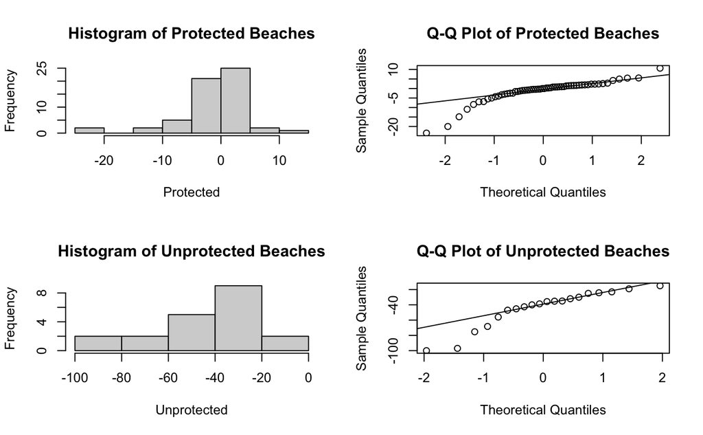

```r
# Extract the data for the two groups: Protected (Group1) and Unprotected (Group2)
Protected <- subset(dataset, beach_type == "Protected")$volume_change_m3_m
Unprotected <- subset(dataset, beach_type == "Unprotected")$volume_change_m3_m


# Step 1: Check Independence (Assumption 1)
# In most cases, you can assume independence since your data is observational.

# Step 2: Check Normality (Assumption 2)
# Visual check for normality using histograms and Q-Q plots.
{par(mfrow = c(2, 2))  # Create a 2x2 grid of plots
hist(Protected, main = "Histogram of Protected Beaches")
qqnorm(Protected, main = "Q-Q Plot of Protected Beaches")
qqline(Protected)

hist(Unprotected, main = "Histogram of Unprotected Beaches")
qqnorm(Unprotected, main = "Q-Q Plot of Unprotected Beaches")
qqline(Unprotected)}
```

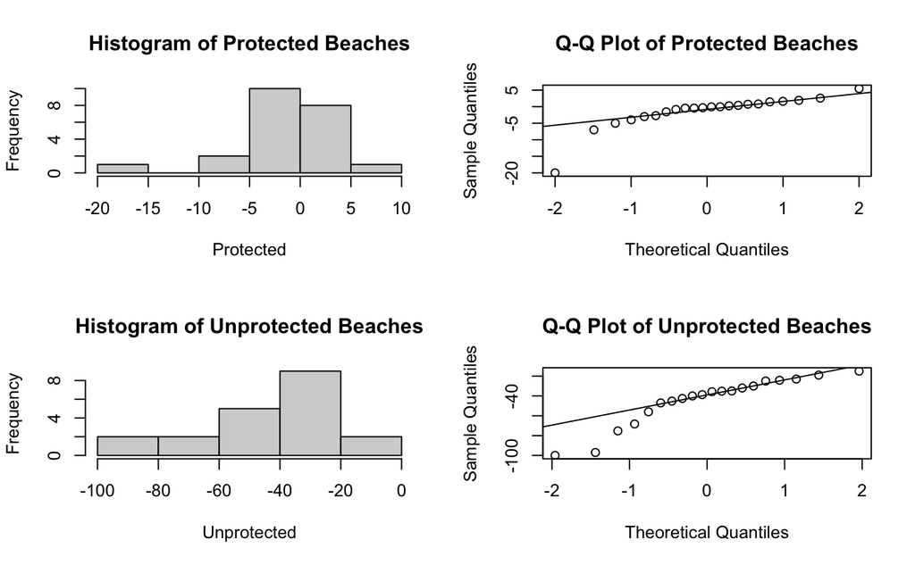

```r
# Extract the data for the two groups: Protected (Group1) and Unprotected (Group2)
Protected <-dataset %>%
    select(c("study", "storm", "significant_wave_height_m","volume_change_m3_m", "beach_type", "waveheight_data_source"))%>%
    filter(storm!="TC Felleng") %>%
    filter(storm!="TC Bejisa") %>%
    subset(beach_type == "Protected")%>%
  pull(volume_change_m3_m)

Unprotected <- subset(dataset, beach_type == "Unprotected")$volume_change_m3_m

# Step 2: Check Normality (Assumption 2)
# Visual check for normality using histograms and Q-Q plots.
{par(mfrow = c(2, 2))  # Create a 2x2 grid of plots
hist(Protected, main = "Histogram of Protected Beaches")
qqnorm(Protected, main = "Q-Q Plot of Protected Beaches")
qqline(Protected)

hist(Unprotected, main = "Histogram of Unprotected Beaches")
qqnorm(Unprotected, main = "Q-Q Plot of Unprotected Beaches")
qqline(Unprotected)}
```

```r
# If the data appear reasonably symmetric in the histograms and follow a straight line in the Q-Q plots,
# the normality assumption may be met.

# Step 3: Check Homogeneity of Variance (Assumption 3)
# Use Levene's test to check for homogeneity of variance.
# install.packages("car")
library(car)
# Perform Levene's test
leveneTest(volume_change_m3_m ~ beach_type, data = dataset)
```

```
Levene's Test for Homogeneity of Variance (center = median)
      Df F value    Pr(>F)
group  1  27.042 1.631e-06 ***
      76
---
Signif. codes:  0 ‘***’ 0.001 ‘**’ 0.01 ‘*’ 0.05 ‘.’ 0.1 ‘ ’ 1
```

```r
# If the p-value from Levene's test is greater than your chosen significance level (e.g., 0.05),
# you can assume homogeneity of variance.

# Assuming all assumptions are met, perform the two-sample t-test.
# Perform a two-sample t-test assuming equal variances (default in R).
t.test(Protected, Unprotected)
```

```
    Welch Two Sample t-test

data:  Protected and Unprotected
t = 7.8348, df = 20.473, p-value = 1.369e-07
alternative hypothesis: true difference in means is not equal to 0
95 percent confidence interval:
 31.45286 54.23239
sample estimates:
 mean of x  mean of y
 -1.367364 -44.209990
```

The dataset is not normally distributed, there are issues with homogeneity of variance, so a parametric test may not be a good option. I will try a non-parametric test: Wilcox

# Non-Parametric Test

Because the data is not normally distributed, I will perform the Mann-Whitney U test.

```r
result
```

```
    Wilcoxon rank sum test with continuity correction

data:  Protected and Unprotected
W = 1155, p-value = 4.893e-11
alternative hypothesis: true location shift is not equal to 0
```

The Wilcox test shows a significant difference between the two groups. Now I will proceed with a simple blot comparing the two groups.

# Plotting Figure

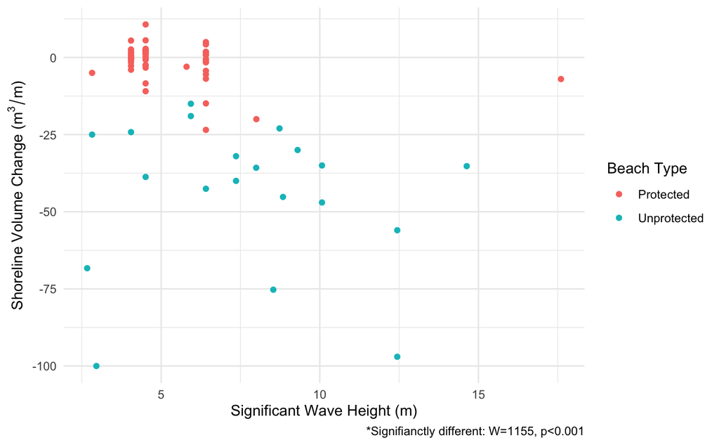